# Introduction to ggplot2 for plotting

Richard Upton  
4 August 2015

# More is missed by not looking than by not knowing

# Thomas McCrae (Physician)

### Plotting is an important part of modeling

- For data exploration before modeling (graphical analysis).
- For assessing model performance (Visual Predictive Checks).
- For showing the predictions of a model (Simulation).
- For publishing modeling results.

### Why use R for plotting?

- Of the statistical software environments, it's the most versatile.
- It's combination of data manipulation and plotting makes it a “one stop shop”.
- It facilliates Reproducible Research and Open Science.

[figure not shown]

### Plotting packages in R

### The **base** package

Pros - quick & easy  
Cons - legends, scales and plotting by factor difficult

### The **lattice** package

Pros - allows plotting by factor  
Cons - fussy syntax, legends and scales difficult

### The **ggplot2** package

Pros - allows plotting by factor, automatic legends and scale  
Cons - slow for large datasets

### The **grid** package

Low level drawing functions (lines, points, text)

### Plotting devices in R

When R draws a plot, it is written to a device.  
Plots can be sent to more than 1 device.  
Plot appearance depends on device settings (e.g. dimensions, dpi).  
The screen plot may look weird when a plot is formated for other devices.

#### Avaliable devices (?devices):

Screen (can copy to clipboard in Windows)  
PDF file  
PNG bitmap file  
JPEG bitmap file

Typically, write to a file then import in Word or Powerpoint.

### A Grammar of Graphics

Wilkinson (2005): A grammar for the components of a graphic:

- data and aesthetic mappings
- geometric objects
- scales
- facet specification
- statistical transformations
- coordinate system (usually cartersian for us)

Instead of *“draw a scatterplot for these data”*.

### ggplot2

ggplot2 - plotting in R based on **A Grammar of Graphics**.  
http://ggplot2.org (Hadley Wickham).

Most popular ploting in package in R (at the moment).  
The core functions are **qplot** and **ggplot**.  
Now forget about **qplot**.

The specifications for a graph and data are contained in a R object.  
The plotting object can be built in layers.

### Data and Aesthetic Mappings

Aesthetics for the plot of data x and y are mapped against two explanatory variables:

| x | y | ID | TRT | aesthetic1 | aesthetic2 |
| --- | --- | --- | --- | --- | --- |
| 0 | 2 | Subject1 | Baseline | red | circle |
| 10 | 3 | Subject1 | Treated | red | triangle |
| 0 | 4 | Subject2 | Baseline | blue | circle |
| 10 | 6 | Subject2 | Treated | blue | triangle |

Plot data (x, y) can be *Discrete* (a factor) or *Continuous*.  
Explanatory variables (ID, TRT) can be *Discrete* or *Continuous*.  
There are aesthetics for: *Colour*, *Shape*, *Size* and *Linetype*.

### Data and Aesthetic Mappings

```r
> exampledata <- read.csv("data_aes.csv")
> exampledata
```

```
   X Y       ID      TRT
1  0 2 Subject1 Baseline
2 10 3 Subject1  Treated
3  0 4 Subject2 Baseline
4 10 6 Subject2  Treated
```

```r
> plotobj <- ggplot(exampledata)
> plotobj <- plotobj + geom_point(aes(x=X, y=Y, shape=TRT, colour=ID))
```

### Data and Aesthetic Mappings

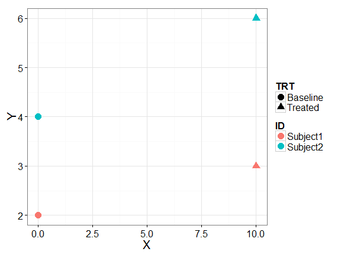

### Geometric Objects

The plot of x and y can be made using a different geometries:  
There is a large toolkit of geometries  
This allows great flexibility in plotting  
Not all combinations of data and geometries are possible

- points
- lines
- boxplot
- ribbon
- errorbar
- step etc.

### Geometric Objects

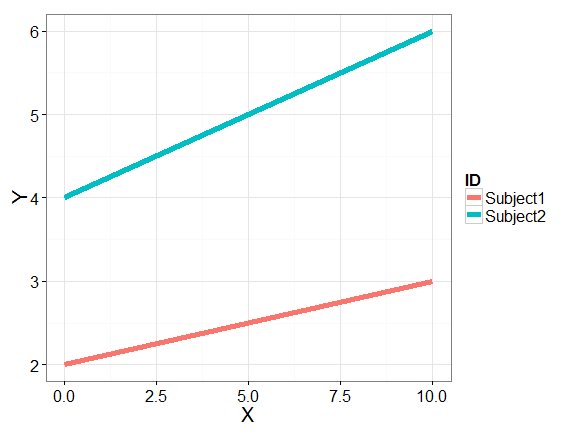

```r
> plotobj <- ggplot(exampledata)
> plotobj <- plotobj + geom_line(aes(x=X, y=Y, colour=ID))
```

### Plots can be built in layers

Two different geometries used in the same plot:

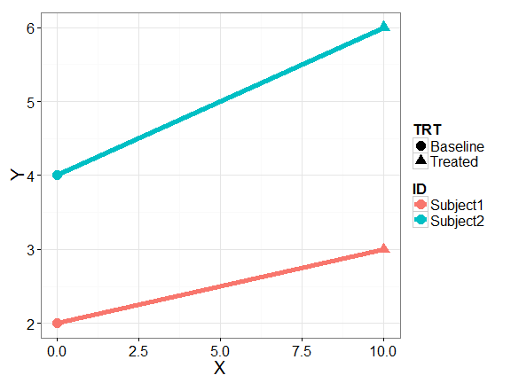

```r
> plotobj <- ggplot(exampledata)
> plotobj <- plotobj + geom_point(aes(x=X, y=Y, shape=TRT, colour=ID))
> plotobj <- plotobj + geom_line(aes(x=X, y=Y, colour=ID))
```

### Scales

The plot of x and y can be made using a different axis scales:

- scale_x_continuous
- scale_y_discrete
- scale_x_log10
- scale_x_reverse
- scale_x_datetime etc.

Within a scale there are arguments for:

- axis label (label)
- axis limits (lim)
- axis tick breaks (breaks)

### Scales

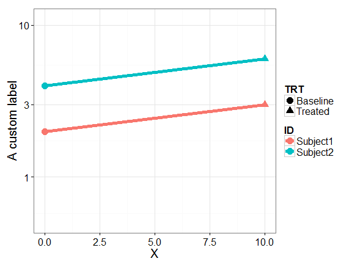

```r
> plotobj <- ggplot(exampledata)
> plotobj <- plotobj + geom_point(aes(x=X, y=Y, shape=TRT, colour=ID))
> plotobj <- plotobj + geom_line(aes(x=X, y=Y, colour=ID))
> plotobj <- plotobj + scale_y_log10("A custom label")
```

### Scales

Scales can also apply to aesthetics:  
Example - a continuous colour scale of rainbow colors  
Example - a discrete colour scale of red, blue & green

- scale_colour_continuous
- scale_colour_discrete
- scale_linetype etc.

### Facetting

The plot of x and y can be facetted into sub-plots:  
This is powerful way to visualize subsets of the data

- facet_wrap
  - ~factor1+factor2
  - a linear series of plots displayed as ncol, rnow
- facet_grid
  - factor1 ~ factor2
  - a grid of plots displayed as factor vs factor

### Facetting

```r
> plotobj <- ggplot(exampledata)
> plotobj <- plotobj + geom_point(aes(x=X, y=Y, shape=TRT, colour=ID))
> plotobj <- plotobj + geom_line(aes(x=X, y=Y, colour=ID))
> plotobj <- plotobj + scale_y_log10("A custom label")
> plotobj <- plotobj + facet_wrap(~ID)
```

### Facetting

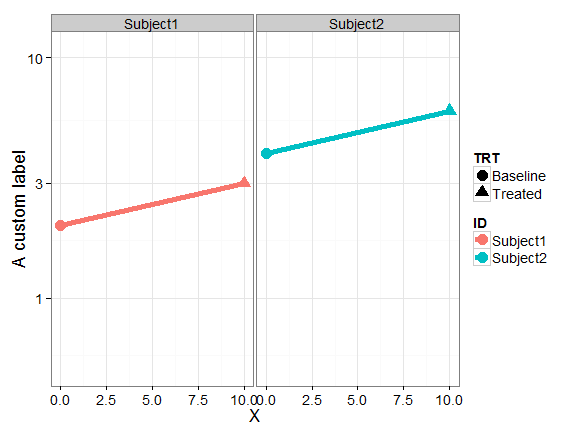

### Statistical Summaries

Statistical summaries can be added to the plot of x and y:

Summary statistics are calculated inside the plot  
This is handy and time-efficient

- stat_summary
- stat_density
- stat_qq
- stat_smooth (Loess, polynomial, linear)

### Statistical Transformations

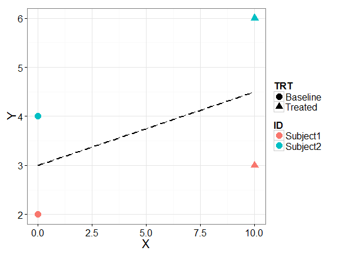

```r
> plotobj <- ggplot(exampledata)
> plotobj <- plotobj + geom_point(aes(x=X, y=Y, shape=TRT, colour=ID))
> plotobj <- plotobj + stat_summary(aes(x=X, y=Y), fun.y=mean, geom="line", linetype="dashed")
```

### Themes and Elements

Themes control the overall look for a plot:  
The standard theme is influenced by Edward Tufte  
some prefer bolder colours  
also see the package “ggthemes”  
publication ready b+w is possible, but obscures information

Elements of a plot can be adjusted individually:  
fonts and font sizes  
legend positions  
plot margins

### Themes and Elements

```r
> plotobj <- ggplot(exampledata)
> plotobj <- plotobj + geom_point(aes(x=X, y=Y, shape=TRT, colour=ID))
> plotobj <- plotobj + scale_x_continuous("This is the X data")
> plotobj <- plotobj + ggtitle("My graph")
> plotobj <- plotobj + theme_gray()
> plotobj <- plotobj + theme(legend.position = "left")
> plotobj <- plotobj + theme(axis.title.x = element_text(colour = "red", face="italic"))
```

### Themes and Elements

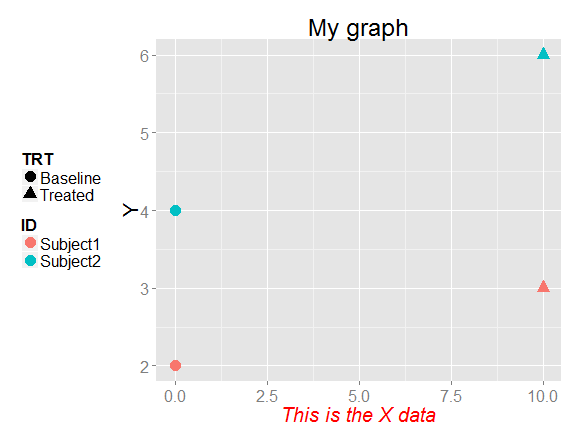

### Saving plots

ggsave is a good place to start  
see also ?devices

ggsave writes the current plot object to a file  
file type is inferred from the extension  
set the height and width as appropropriate

```r
> plotobj <- ggplot(exampledata)
> plotobj <- plotobj + geom_point(aes(x=X, y=Y, shape=TRT, colour=ID))
> ggsave("myplot.png", width=5,height=4)
```

### Summary: ggplot2

**ggplot2** is evolving as a key method for data visualization

Pros:  
It's reproducible  
Script based plotting makes complicated plots easy  
Quickly reshape plots to investigate relationships  
Code can be recycled

Cons:  
It discourages “stupid” plots (pie charts, 2 y axes)  
Fine control over plots sometimes frustrating (subscripts, superscripts)  
There is a learning-curve folks

[figure not shown]

### Installing packages

This will be the first time we have used a package

Packages need to be *installed* once in your version of R  
Do this from the Packages\Install Package(s) menu  
Select a CRAN mirror  
Select the package by name  
They can also be installed from a downloaded zip file

Packages need to be *loaded* once in each session of R  
do this with the library function: library(ggplot2)

If a script can't find a function, it's package may not be loaded

You can review your installed packages with installed.packages()